# TLAC Dog Walking

Hunter Ratliff

November 8, 2015

# General information

About

The goal of this analysis is to explore data pulled from [Vol2](https://app.betterimpact.com/Login/Admin) (i.e. Better Impact or http://MyVolunteerPage.com) about the Dog Walkers at Austin Pets Alive’s main campus, [Town Lake Animal Center](https://goo.gl/maps/zxc3AtzTifH2) (TLAC).

[figure not shown]

### Data set

```
DatabaseActivityCategoryId:
> IDs: 54883
Dates:
> Start: 2015-08-01
> End:   2015-11-06
```

### Purpose

We’ve had some unusual weather patterns recently, as Austin has had more than it’s fair share of bad weather days. I’m concerned that the poor weather has negatively influenced our volunteer engagement, particularly for activities that are outdoors like dog walking. I’ve also incidentally observed that the shelter lacks the same volunteer base during weekdays as we do on weekends, and it’s really a few dedicated volunteers who regularly walk dogs during these less than desirable times.

Therefore, the purpose of this analysis is to investigate these observations, and if my intuition is correct, identify explanatory variables for this disparity in engagement. Finally, I’d like to recognize the volunteers who remain dedicated to walking dogs, irregardless of the time of the week or the weather.

# Plots

```
##       Date                                              Activity
##  Min.   :2014-01-01   Dog Walking                           :16870
##  1st Qu.:2014-09-06   RuffTail Runner                       : 3495
##  Median :2015-02-04   New Volunteers - Mentor Sessions 1 & 2: 1424
##  Mean   :2015-01-24   Support                               : 1136
##  3rd Qu.:2015-06-17   Kennel Tech                           : 1076
##  Max.   :2015-11-08   Mentor a New Volunteer                :  587
##                       (Other)                               : 2352
##      Hours                          Name
##  Min.   :  0.00   Melissa Foester     :  540
##  1st Qu.:  1.09   Jess Borda          :  525
##  Median :  1.75   Leora Orent         :  407
##  Mean   :  2.28   Michelle Habecker   :  339
##  3rd Qu.:  2.58   Jenna de Graffenried:  325
##  Max.   :264.00   Larry Ellman        :  292
##                   (Other)             :24512
##      Start                          End
##  Min.   :2014-01-06 16:02:00   Min.   :2014-01-06 16:04:00
##  1st Qu.:2014-09-17 09:40:30   1st Qu.:2014-09-17 13:11:30
##  Median :2015-02-09 14:11:00   Median :2015-02-09 15:23:00
##  Mean   :2015-02-01 23:36:14   Mean   :2015-02-02 01:35:36
##  3rd Qu.:2015-06-20 14:17:00   3rd Qu.:2015-06-20 16:18:00
##  Max.   :2015-11-08 18:04:00   Max.   :2015-11-08 20:08:00
##  NA's   :7153                  NA's   :7153
##     User.ID             Type
##  1808572:  540   Logged   : 7153
##  1605229:  525   Timeclock:19787
##  1721188:  407
##  1796618:  339
##  1720293:  325
##  1721307:  292
##  (Other):24512
```

### Total Hours Logged

This graphic is looking at the total number of hours logged (the numbers) in respect to the number of volunteers who logged hours (the red to green coloring). This only measures hours logged under Dog walking and Rufftail Runners (RTR) and is grouped by date.

It’s broken down by day of the week on the x-axis, and the week on the y-axis. A blue number indicates that day had thunderstorms, a black number indicates rain, and a grey number indicates that there was no weather activities recorded.

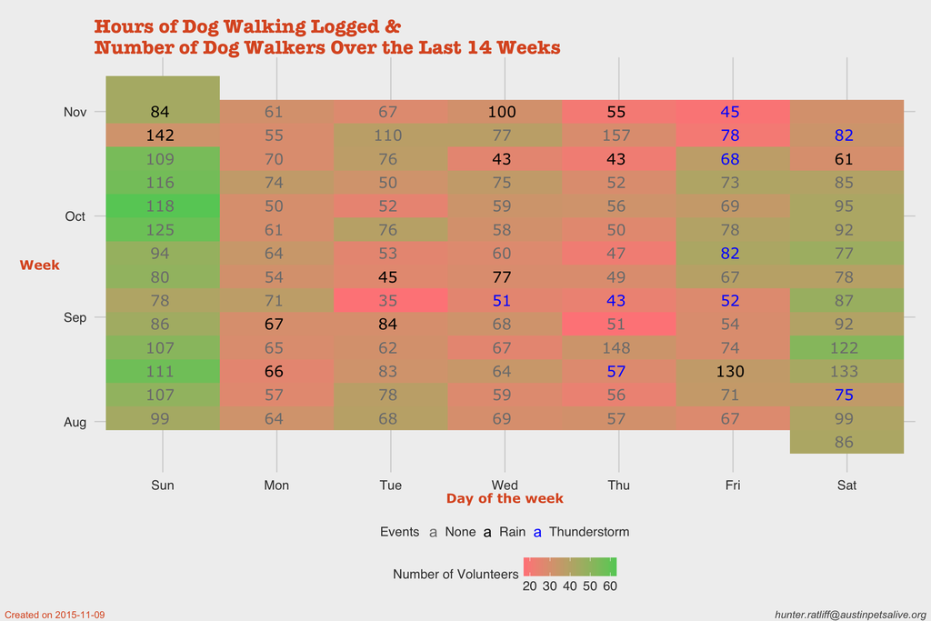

### Number of Volunteers

**Density**  
This plot is a density plot of the daily number of volunteers who walked dogs. It’s broken down by three “weather events”: Thunderstorm (dark blue), Rain (light blue), and no weather event (white).

Note: There is significant crossover among groups, so there are some areas that may appear to be light blue, when it’s actually just a crossover of white and dark blue.

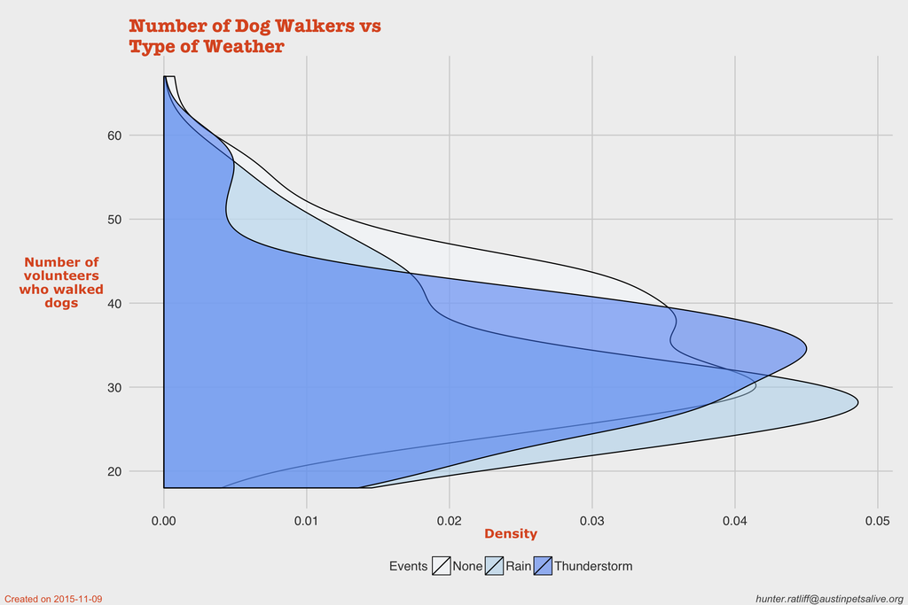

**Boxplot**  
This plot is factored with a boxplot representing each weather event (using the same color scheme as before). Again, the the daily number of volunteers who walked dogs is represented on the y-axis.

Plotted on top of the boxplot are points representing each day within that weather event-type. The points are further divided by shape representing the day of the week and color representing the “wetness” that day.

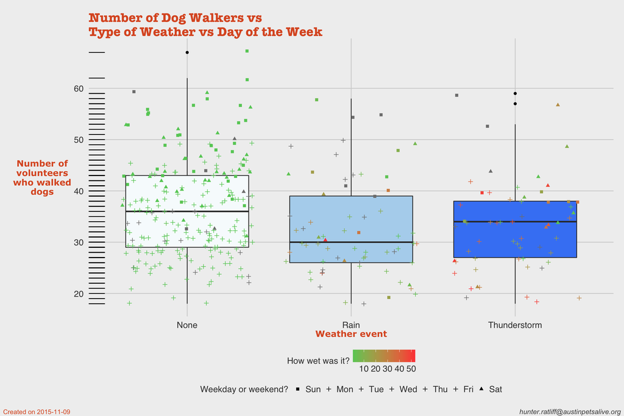

**Violin**

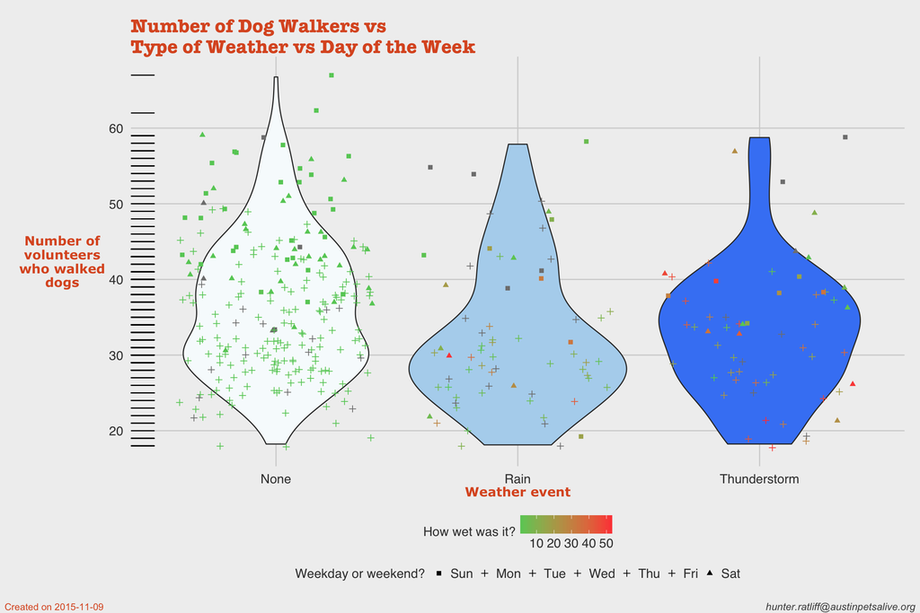

### Heatmap of Start Time and End Time

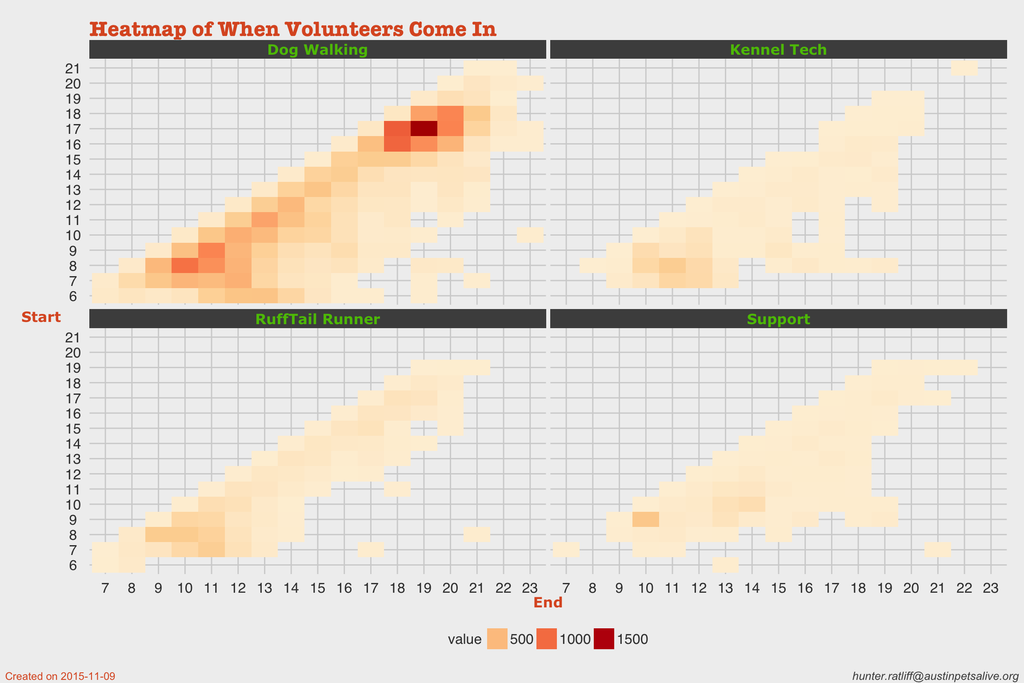

### GIFs

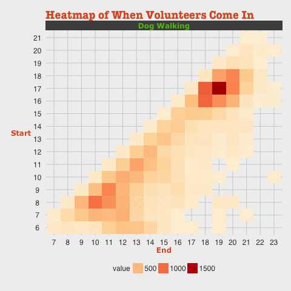

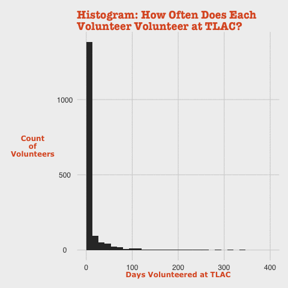

[figure not shown]

# Statisitical models

**Disclaimer:** This section is still a work in progress!

## Number of Volunteers

### Linear Model

```
##
## Call:
## lm(formula = NumVols ~ Prec + Wind + week(Date) + wkday, data = df.mat,
##     weights = sum)
##
## Weighted Residuals:
##     Min      1Q  Median      3Q     Max
## -158.01  -46.47  -11.08   27.83  185.47
##
## Coefficients:
##             Estimate Std. Error t value Pr(>|t|)
## (Intercept) 43.89012    1.27653  34.382  < 2e-16 ***
## PrecTRUE    -5.30954    0.85344  -6.221 1.61e-09 ***
## Wind        -0.34761    0.11615  -2.993  0.00299 **
## week(Date)  -0.11897    0.02632  -4.521 8.80e-06 ***
## wkday.L     -3.14183    0.96333  -3.261  0.00123 **
## wkday.Q     13.08303    0.96982  13.490  < 2e-16 ***
## wkday.C     -0.79864    1.01647  -0.786  0.43265
## wkday^4      6.21076    1.03490   6.001 5.49e-09 ***
## wkday^5     -3.11032    1.06562  -2.919  0.00377 **
## wkday^6      1.07868    1.05452   1.023  0.30715
## ---
## Signif. codes:  0 '***' 0.001 '**' 0.01 '*' 0.05 '.' 0.1 ' ' 1
##
## Residual standard error: 59.6 on 308 degrees of freedom
##   (50 observations deleted due to missingness)
## Multiple R-squared:  0.5055, Adjusted R-squared:  0.4911
## F-statistic: 34.99 on 9 and 308 DF,  p-value: < 2.2e-16
```

### General Linear Model

```
##
## Call:
## glm(formula = NumVols ~ Prec + Wind + week(Date) + wkday, data = df.mat,
##     weights = sum)
##
## Deviance Residuals:
##     Min       1Q   Median       3Q      Max
## -158.01   -46.47   -11.08    27.83   185.47
##
## Coefficients:
##             Estimate Std. Error t value Pr(>|t|)
## (Intercept) 43.89012    1.27653  34.382  < 2e-16 ***
## PrecTRUE    -5.30954    0.85344  -6.221 1.61e-09 ***
## Wind        -0.34761    0.11615  -2.993  0.00299 **
## week(Date)  -0.11897    0.02632  -4.521 8.80e-06 ***
## wkday.L     -3.14183    0.96333  -3.261  0.00123 **
## wkday.Q     13.08303    0.96982  13.490  < 2e-16 ***
## wkday.C     -0.79864    1.01647  -0.786  0.43265
## wkday^4      6.21076    1.03490   6.001 5.49e-09 ***
## wkday^5     -3.11032    1.06562  -2.919  0.00377 **
## wkday^6      1.07868    1.05452   1.023  0.30715
## ---
## Signif. codes:  0 '***' 0.001 '**' 0.01 '*' 0.05 '.' 0.1 ' ' 1
##
## (Dispersion parameter for gaussian family taken to be 3551.953)
##
##     Null deviance: 2212528  on 317  degrees of freedom
## Residual deviance: 1094002  on 308  degrees of freedom
##   (50 observations deleted due to missingness)
## AIC: 2144
##
## Number of Fisher Scoring iterations: 2
```

## Sum of hours logged

### Linear Model

```
##
## Call:
## lm(formula = sum ~ Wind + Prec + week(Date) + wkday, data = df.mat,
##     weights = NumVols)
##
## Weighted Residuals:
##     Min      1Q  Median      3Q     Max
## -185.91  -84.59  -29.68   37.37  484.03
##
## Coefficients:
##             Estimate Std. Error t value Pr(>|t|)
## (Intercept) 93.37963    3.71059  25.166  < 2e-16 ***
## Wind        -0.75557    0.33521  -2.254   0.0249 *
## PrecTRUE    -6.66394    2.47604  -2.691   0.0075 **
## week(Date)  -0.19964    0.07572  -2.637   0.0088 **
## wkday.L     -0.59418    2.77565  -0.214   0.8306
## wkday.Q     28.52365    2.78021  10.260  < 2e-16 ***
## wkday.C      0.13664    2.91744   0.047   0.9627
## wkday^4     13.44560    2.98520   4.504 9.47e-06 ***
## wkday^5     -7.88815    3.05475  -2.582   0.0103 *
## wkday^6      0.30503    3.02774   0.101   0.9198
## ---
## Signif. codes:  0 '***' 0.001 '**' 0.01 '*' 0.05 '.' 0.1 ' ' 1
##
## Residual standard error: 115.4 on 308 degrees of freedom
##   (50 observations deleted due to missingness)
## Multiple R-squared:  0.3406, Adjusted R-squared:  0.3214
## F-statistic: 17.68 on 9 and 308 DF,  p-value: < 2.2e-16
```

### General Linear Model

```
##
## Call:
## glm(formula = sum ~ Wind + Prec + week(Date) + wkday, data = df.mat,
##     weights = NumVols)
##
## Deviance Residuals:
##     Min       1Q   Median       3Q      Max
## -185.91   -84.59   -29.68    37.37   484.03
##
## Coefficients:
##             Estimate Std. Error t value Pr(>|t|)
## (Intercept) 93.37963    3.71059  25.166  < 2e-16 ***
## Wind        -0.75557    0.33521  -2.254   0.0249 *
## PrecTRUE    -6.66394    2.47604  -2.691   0.0075 **
## week(Date)  -0.19964    0.07572  -2.637   0.0088 **
## wkday.L     -0.59418    2.77565  -0.214   0.8306
## wkday.Q     28.52365    2.78021  10.260  < 2e-16 ***
## wkday.C      0.13664    2.91744   0.047   0.9627
## wkday^4     13.44560    2.98520   4.504 9.47e-06 ***
## wkday^5     -7.88815    3.05475  -2.582   0.0103 *
## wkday^6      0.30503    3.02774   0.101   0.9198
## ---
## Signif. codes:  0 '***' 0.001 '**' 0.01 '*' 0.05 '.' 0.1 ' ' 1
##
## (Dispersion parameter for gaussian family taken to be 13310.85)
##
##     Null deviance: 6217609  on 317  degrees of freedom
## Residual deviance: 4099740  on 308  degrees of freedom
##   (50 observations deleted due to missingness)
## AIC: 2812.8
##
## Number of Fisher Scoring iterations: 2
```